# 白葡萄酒质量数据探索分析

# 数据集概述

本报告探索了白葡萄酒质量数据集。数据集包含4,898种葡萄酒，及11个量化每种酒化学成分的变量。至少 3名葡萄酒专家对每种酒的质量进行了评分，分数在0（非常差）和10（非常好）之间。

现在导入数据集。

## 单变量绘图选择

```
## [1] 4898   12
```

```
## 'data.frame':    4898 obs. of  12 variables:
##  $ fixed.acidity       : num  7 6.3 8.1 7.2 7.2 8.1 6.2 7 6.3 8.1 ...
##  $ volatile.acidity    : num  0.27 0.3 0.28 0.23 0.23 0.28 0.32 0.27 0.3 0.22 ...
##  $ citric.acid         : num  0.36 0.34 0.4 0.32 0.32 0.4 0.16 0.36 0.34 0.43 ...
##  $ residual.sugar      : num  20.7 1.6 6.9 8.5 8.5 6.9 7 20.7 1.6 1.5 ...
##  $ chlorides           : num  0.045 0.049 0.05 0.058 0.058 0.05 0.045 0.045 0.049 0.044 ...
##  $ free.sulfur.dioxide : num  45 14 30 47 47 30 30 45 14 28 ...
##  $ total.sulfur.dioxide: num  170 132 97 186 186 97 136 170 132 129 ...
##  $ density             : num  1.001 0.994 0.995 0.996 0.996 ...
##  $ pH                  : num  3 3.3 3.26 3.19 3.19 3.26 3.18 3 3.3 3.22 ...
##  $ sulphates           : num  0.45 0.49 0.44 0.4 0.4 0.44 0.47 0.45 0.49 0.45 ...
##  $ alcohol             : num  8.8 9.5 10.1 9.9 9.9 10.1 9.6 8.8 9.5 11 ...
##  $ quality             : int  6 6 6 6 6 6 6 6 6 6 ...
```

```
##  fixed.acidity    volatile.acidity  citric.acid     residual.sugar
##  Min.   : 3.800   Min.   :0.0800   Min.   :0.0000   Min.   : 0.600
##  1st Qu.: 6.300   1st Qu.:0.2100   1st Qu.:0.2700   1st Qu.: 1.700
##  Median : 6.800   Median :0.2600   Median :0.3200   Median : 5.200
##  Mean   : 6.855   Mean   :0.2782   Mean   :0.3342   Mean   : 6.391
##  3rd Qu.: 7.300   3rd Qu.:0.3200   3rd Qu.:0.3900   3rd Qu.: 9.900
##  Max.   :14.200   Max.   :1.1000   Max.   :1.6600   Max.   :65.800
##    chlorides       free.sulfur.dioxide total.sulfur.dioxide
##  Min.   :0.00900   Min.   :  2.00      Min.   :  9.0
##  1st Qu.:0.03600   1st Qu.: 23.00      1st Qu.:108.0
##  Median :0.04300   Median : 34.00      Median :134.0
##  Mean   :0.04577   Mean   : 35.31      Mean   :138.4
##  3rd Qu.:0.05000   3rd Qu.: 46.00      3rd Qu.:167.0
##  Max.   :0.34600   Max.   :289.00      Max.   :440.0
##     density             pH          sulphates         alcohol
##  Min.   :0.9871   Min.   :2.720   Min.   :0.2200   Min.   : 8.00
##  1st Qu.:0.9917   1st Qu.:3.090   1st Qu.:0.4100   1st Qu.: 9.50
##  Median :0.9937   Median :3.180   Median :0.4700   Median :10.40
##  Mean   :0.9940   Mean   :3.188   Mean   :0.4898   Mean   :10.51
##  3rd Qu.:0.9961   3rd Qu.:3.280   3rd Qu.:0.5500   3rd Qu.:11.40
##  Max.   :1.0390   Max.   :3.820   Max.   :1.0800   Max.   :14.20
##     quality
##  Min.   :3.000
##  1st Qu.:5.000
##  Median :6.000
##  Mean   :5.878
##  3rd Qu.:6.000
##  Max.   :9.000
```

该数据集有12个变量，4898个观察值。下面将对质量、固定酸度、挥发酸、含糖量、密度、酸碱度、酒精含量等12个特征进行单个变量探索分析。

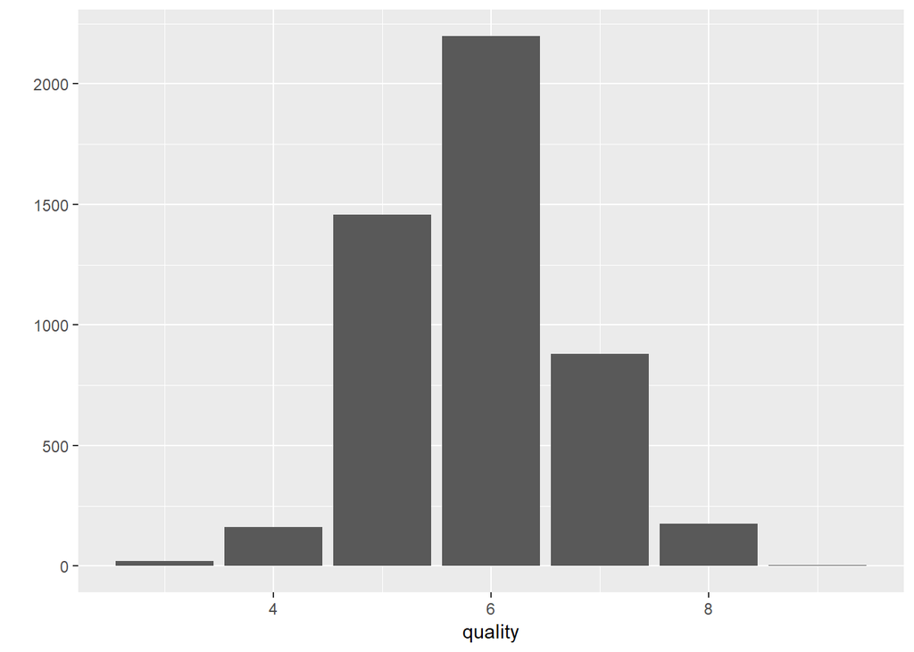

对白葡萄酒质量数据进行分析。得出白葡萄酒质量很差和很好的酒的数量都相对较少，白葡萄酒的质量评分主要分布在6。下面对白葡萄酒的质量进行等级分组并绘制图形进行探索。

```
## quality_level
##   best   good medium  worse
##      5   1055   3655    183
```

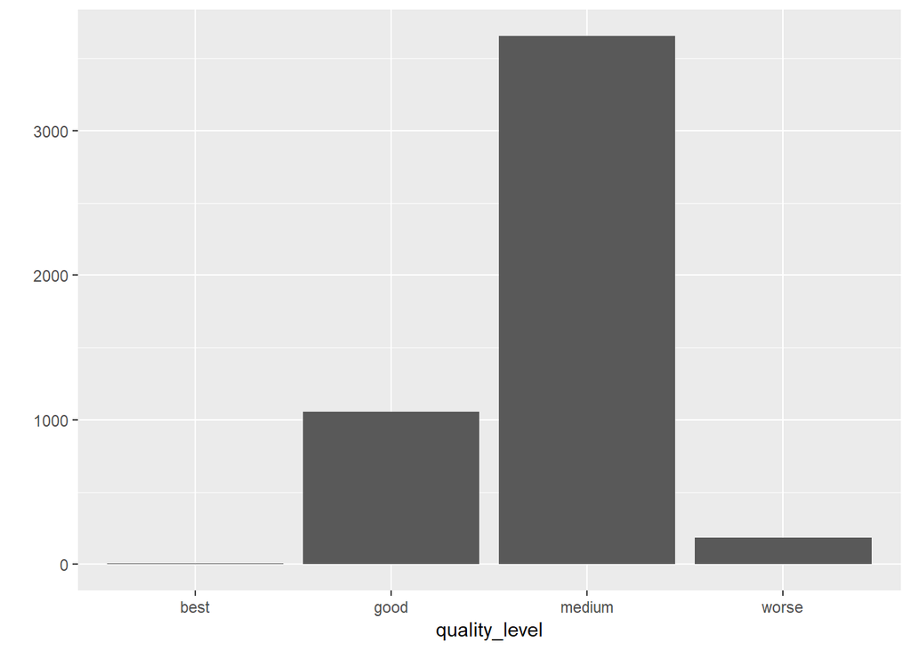

对质量等级进行探索发现，大多数白葡萄酒质量属于中等，差、好、很好质量的白葡萄酒分布较少，从这份数据集中没有看到很差质量的白葡萄酒分布。

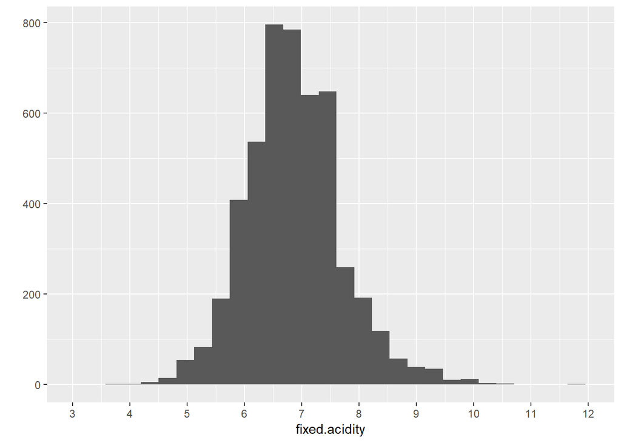

对白葡萄酒的固定酸度进行绘图分析。得出白葡萄酒的固定酸度主要分布在6-7.5之间，酸度很低或者很高的分布相对较少。

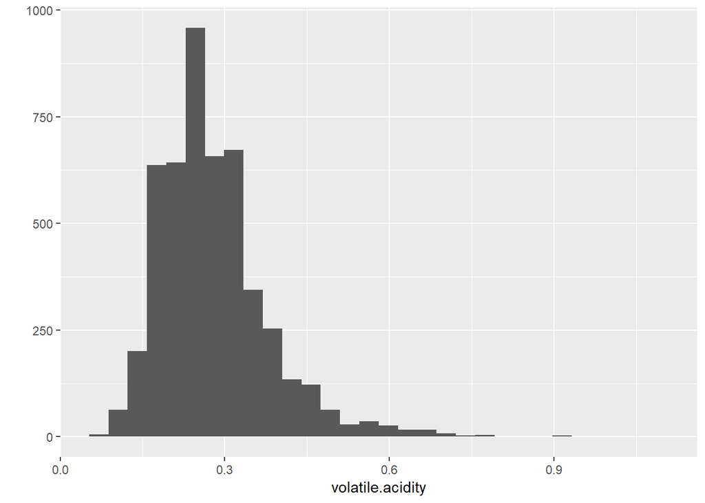

对白葡萄酒的挥发性酸进行分析，得出白葡萄酒的挥发酸度主要集中在0.15-0.35之间。挥发性酸偏高的或者极低的分布少。

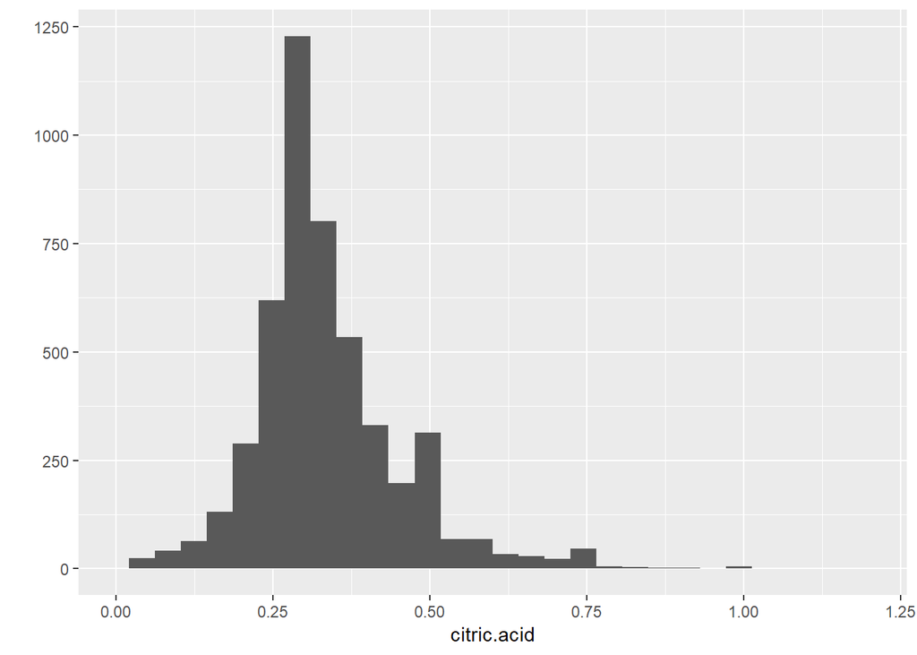

对白葡萄酒中的柠檬酸分析发现，柠檬符合正太分布的趋势，主要分布在0.25-0.37之间。

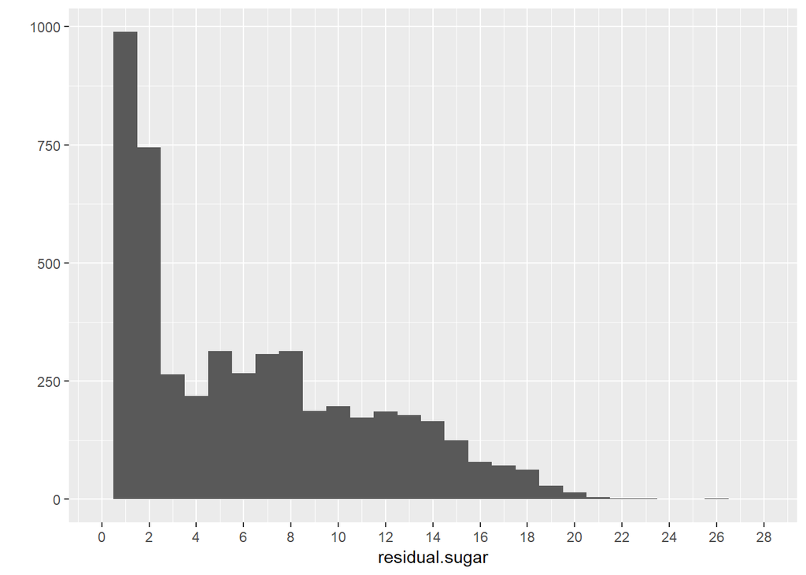

对白葡萄酒的含糖量量进行分析发现，含糖量含量主要分布在很低的水平，甜度较高的白葡萄酒偏少。下面含糖量进行等级分组并绘图探索。

```
## residual.sugar_level
##     Dry Off-Dry   Sweet
##    2645    2244       9
```

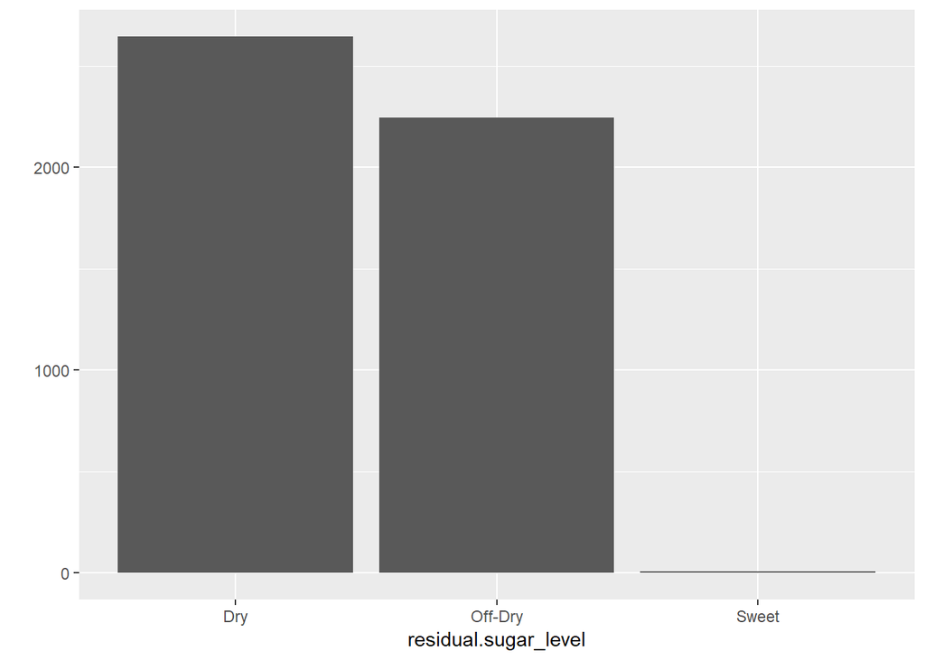

白葡萄酒含糖量主要分布在Dry-Dry,甜分布极少，很甜的甚至从这份数据集中看不到。

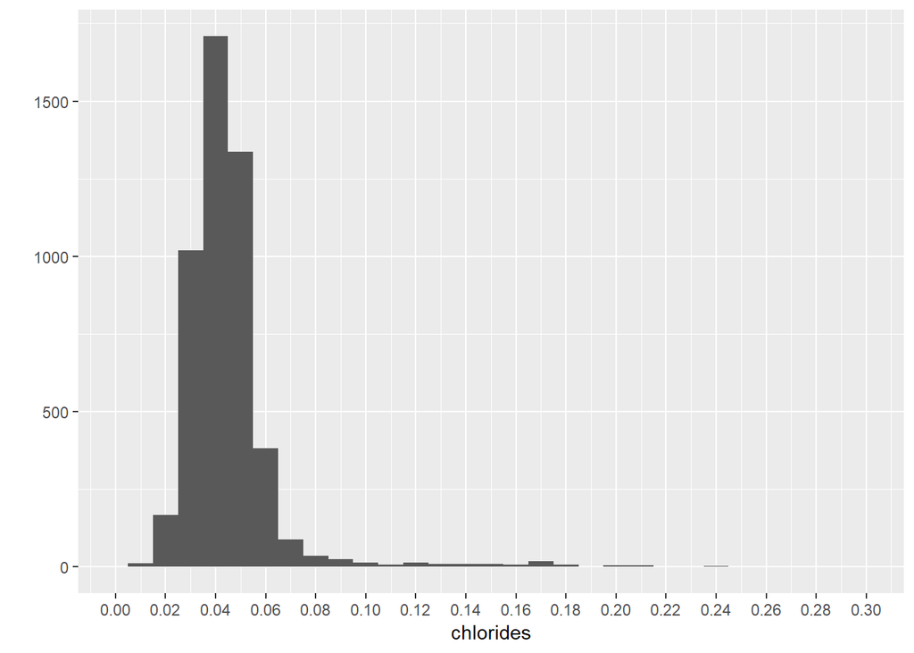

白葡萄酒中的含盐量主要分布在0.03-0.05之间，含盐量含量在0.01、0.06-0.24之间的很少。

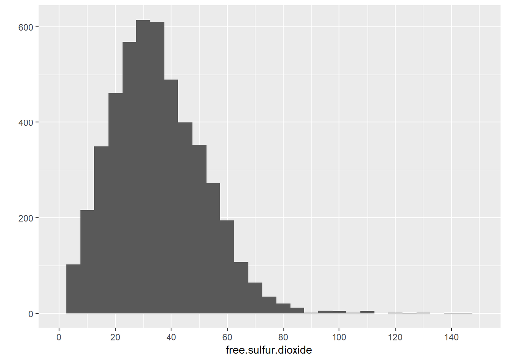

白葡萄酒中的游离的硫离子主要分布在5-60之间。

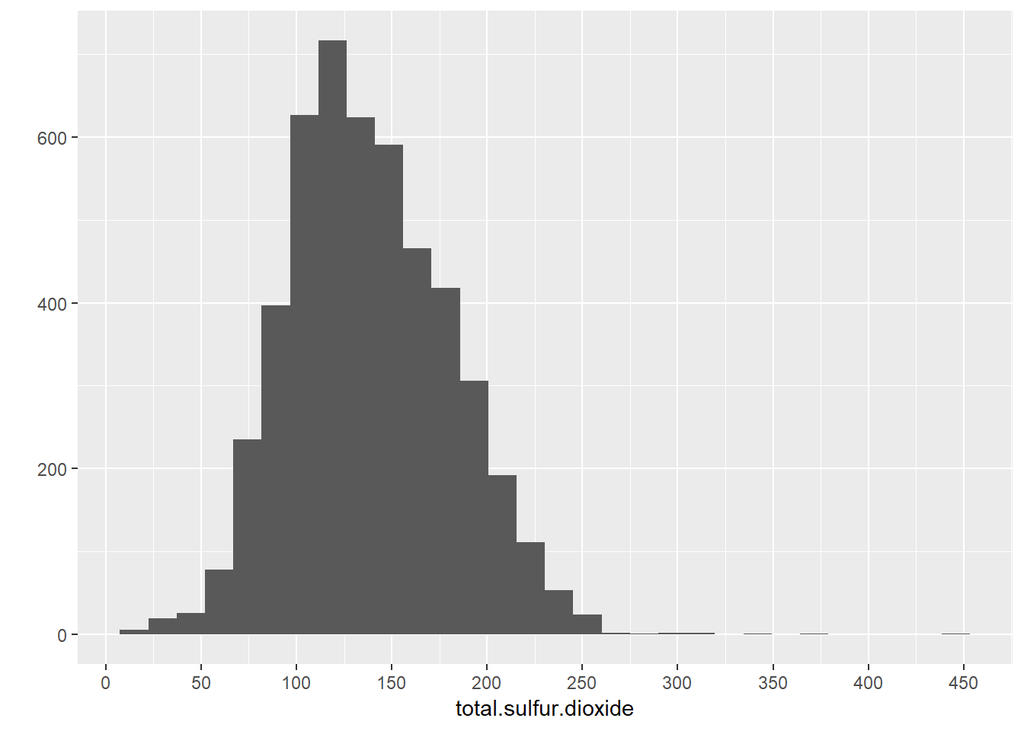

白葡萄酒中二氧化硫的含量主要集中在100-175之间。可见，白葡萄酒中的二氧化硫含量大多数处于中等水平。

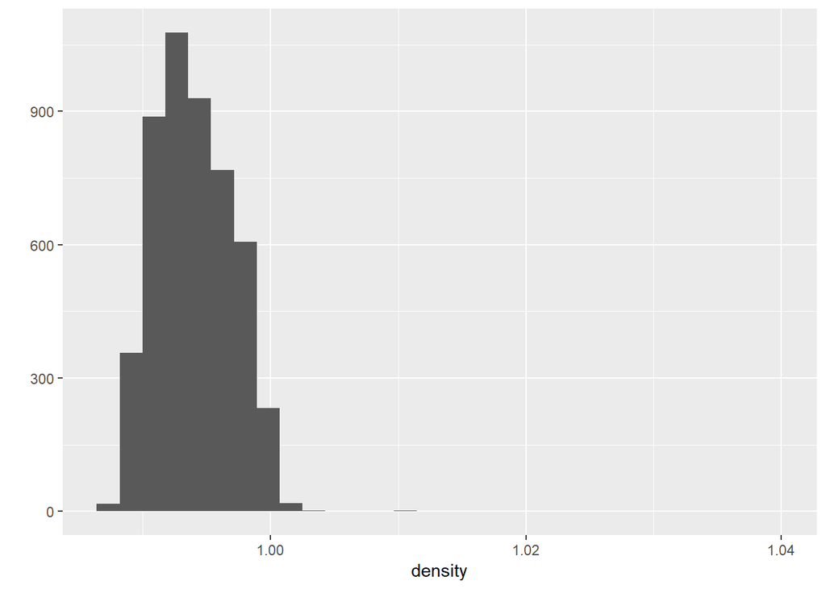

对白葡萄酒的密度分析发现，白葡萄酒的密度主要分布在0.99-1之间，与水的密度很接近。

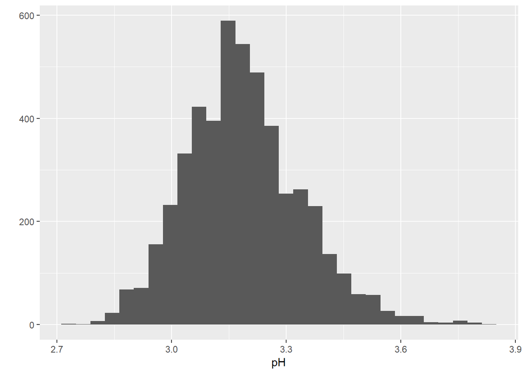

```
##    Min. 1st Qu.  Median    Mean 3rd Qu.    Max.
##   2.720   3.090   3.180   3.188   3.280   3.820
```

对白葡萄酒的酸碱度分析发现，白葡萄酒的PH值主要分布在3-3.3。对其进行描述性统计得出，中位数和平均值3.18和3.188。白葡萄酒普遍偏酸性。

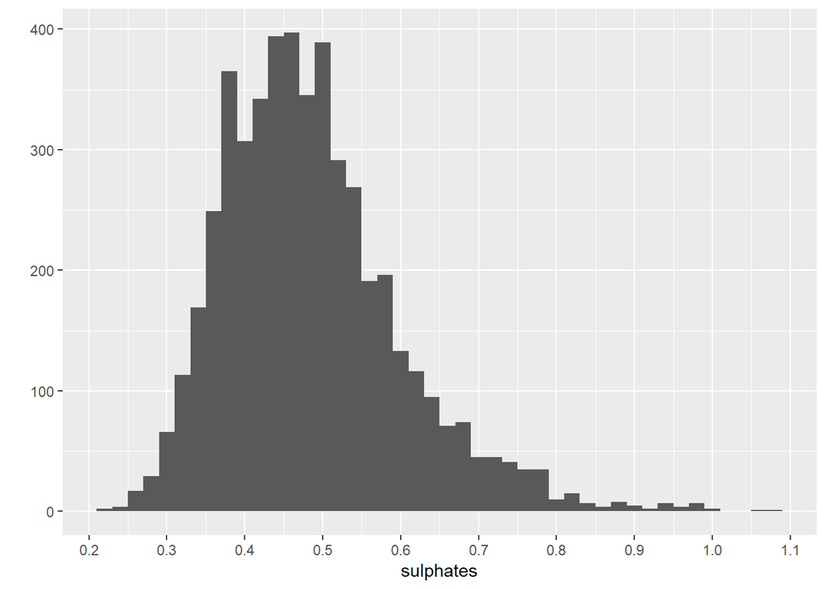

白葡萄酒中硫酸盐含量主要分布在0.35-0.55之间。硫酸盐含量较高的比较少。

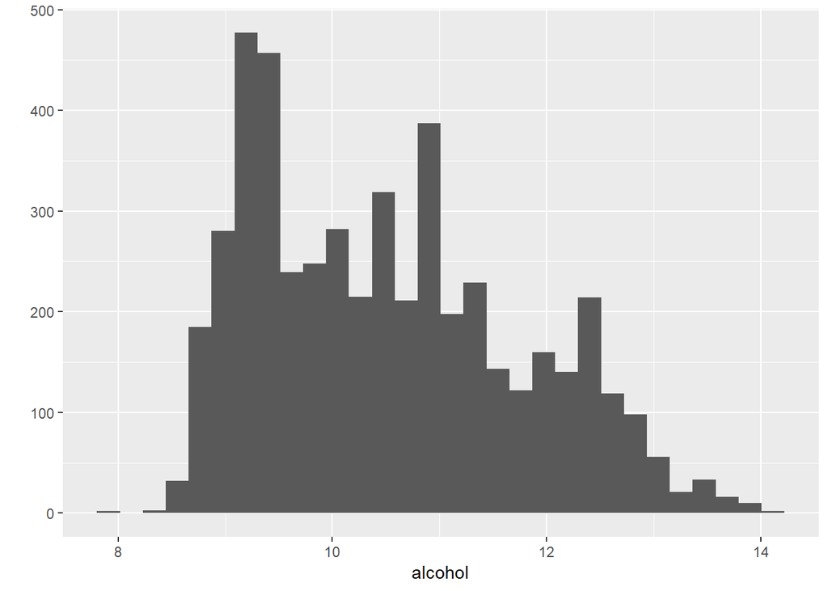

```
##    Min. 1st Qu.  Median    Mean 3rd Qu.    Max.
##    8.00    9.50   10.40   10.51   11.40   14.20
```

通过对白葡萄酒的酒精含量分析得出，白葡萄酒的含量主要分布在9%-11%之间。对其中位数和平均值分析发现，酒精含量分别为你10.4%、10.51%。酒精含量特别低或者酒精含量很高的分布较少，可见白葡萄酒的酒精含量较低。

# 单变量分析

### 你的数据集结构是什么？

数据集中有4898种白葡萄酒，有12个特征（固定酸度，挥发酸，柠檬酸，含糖量，含盐量，游离硫元素，总共硫含量，密度，酸碱度，添加剂，酒精含量，质量）质量是整型，按照0（非常差）-10（非常好）分不等。其他特征是数字类型。

其他观察：  
- 挥发酸含量过高会导致葡萄酒味道不好，白葡萄酒的挥发酸主要分布在较低的数值间。  
- 少量柠檬酸可以增加葡萄酒的风味。  
- 白葡萄酒的PH值大多数是3-4之间。  
- 白葡萄酒的质量等级在中等水平的居多。  
- 白葡萄酒的含糖量主要在干燥水平，甜或者很甜的分布很少。

### 你的数据集内感兴趣的主要特性有哪些？

我希望通过该数据集研究哪个化学成分影响白葡萄酒的质量。我认为固定酸、挥发酸、含糖量、密度、PH、酒精含量都有可能影响白葡萄酒的质量，可能会是这些特征组合起来觉得白葡萄酒的质量。

### 你认为数据集内哪些其他特征可以帮助你探索兴趣特点？

固定酸、挥发酸、含糖量、密度、PH、酒精含量这些特征，或者这些特征与其他特征的组合都可以帮助我进行数据分析探索。

### 根据数据集内已有变量，你是否创建了任何新变量？

目前对数据集中的质量、含糖量进行了等级划分，这样清楚的了解白葡萄酒的质量水平区间以及白葡萄酒的甜度水平。

### 在已经探究的特性中，是否存在任何异常分布？你是否对数据进行一些操作，如清洁、调整或改变数据的形式？如果是，你为什么会这样做？

目前已经对固定酸、挥发酸、含糖量、密度、PH、酒精含量及质量等特征进行了单变量探索，暂时只能得出这些特征的分布情况，还无法确认哪些特征会影响其质量，下面将进一步探索白葡萄酒的特征是否存在相关性。

# 双变量绘图选择

1、首先探索各个变量之间的相关性。

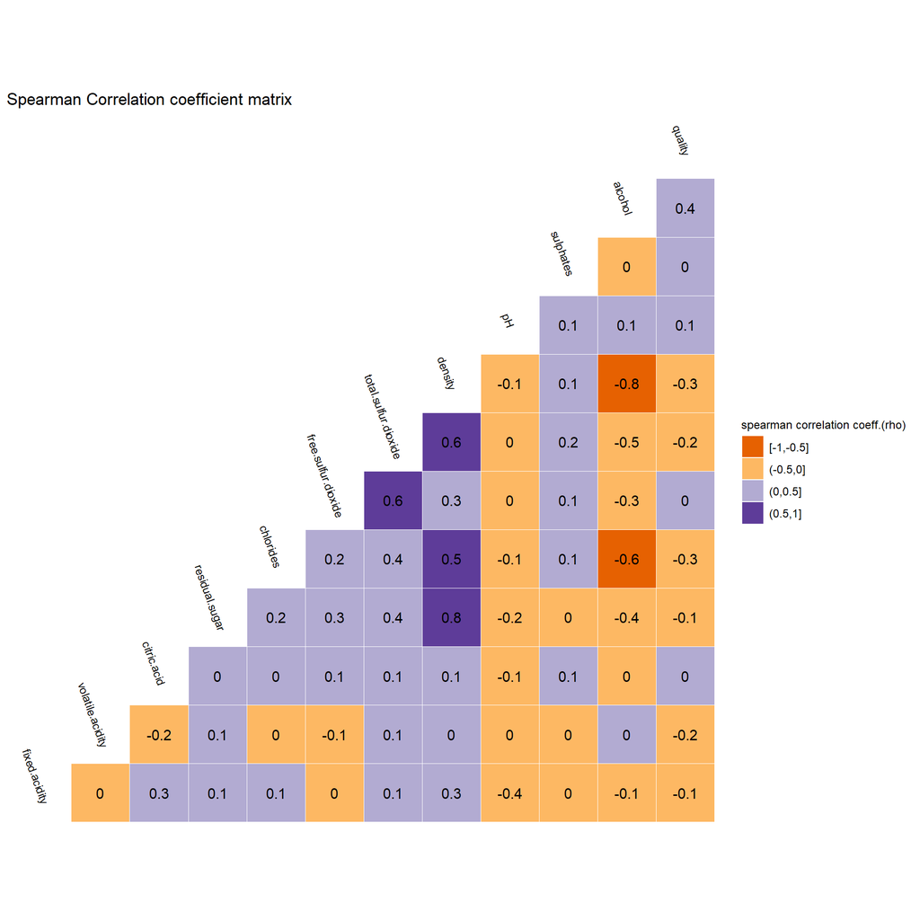

由以上的分析发现密度与chlorides、residual.sugar、 total.sulfur.dioxide具有很强的相关性。白酒的质量评分也与酒精浓度、PH几个特征有相关性。

2、下面对白葡萄酒的密度进行探索。

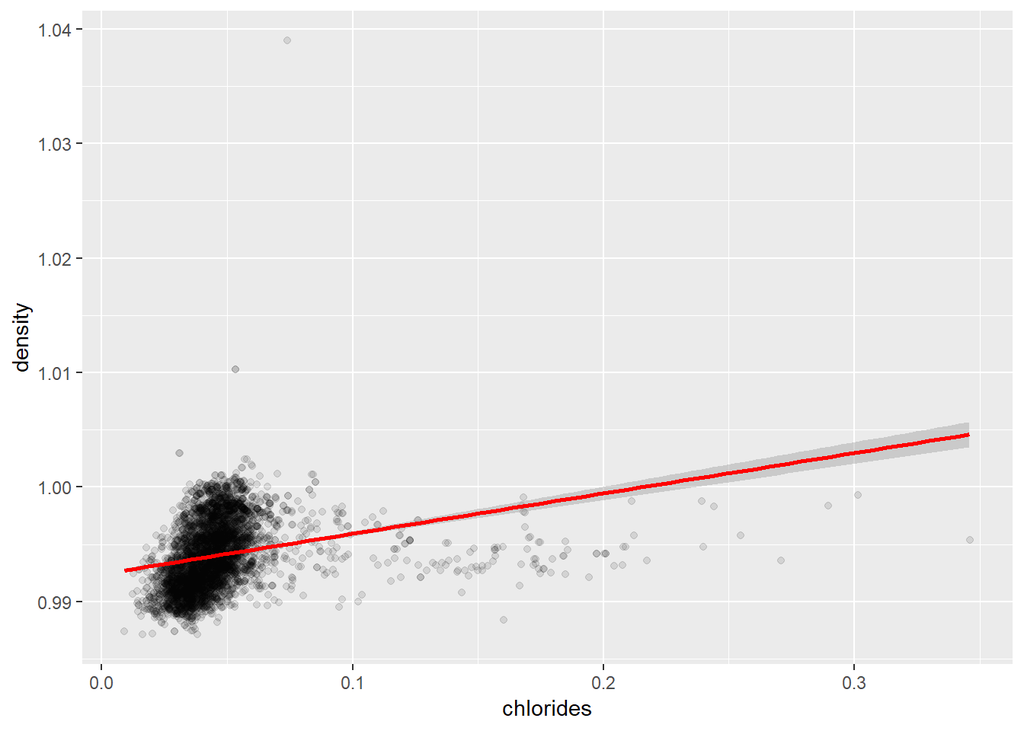

```
##
##  Pearson's product-moment correlation
##
## data:  wine_data$chlorides and wine_data$density
## t = 18.624, df = 4896, p-value < 2.2e-16
## alternative hypothesis: true correlation is not equal to 0
## 95 percent confidence interval:
##  0.2308679 0.2831779
## sample estimates:
##       cor
## 0.2572113
```

对白葡萄酒的含盐量与密度进行绘图发现，两者之间存在着一定的相关性。求解其相关系数得出，相关系数是0.257，相关性中等。

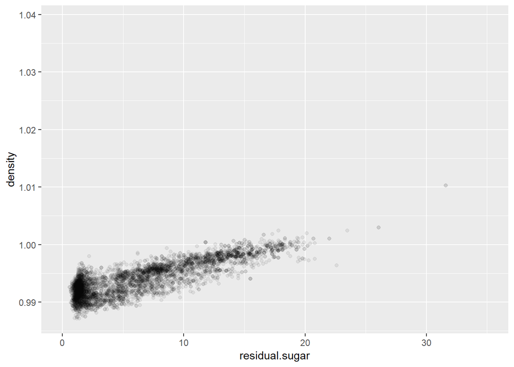

通过含糖量与密度之间的散点图发现，随着含糖量的增加，密度逐渐增加。两者之间存在着很强的正相关。下面计算其两者之间的相关系数。

```
##
##  Pearson's product-moment correlation
##
## data:  wine_data$residual.sugar and wine_data$density
## t = 107.87, df = 4896, p-value < 2.2e-16
## alternative hypothesis: true correlation is not equal to 0
## 95 percent confidence interval:
##  0.8304732 0.8470698
## sample estimates:
##       cor
## 0.8389665
```

相关系数为0.84，含糖量与密度存在着很大的相关性。绘制含糖量等级与密度之间的关系。

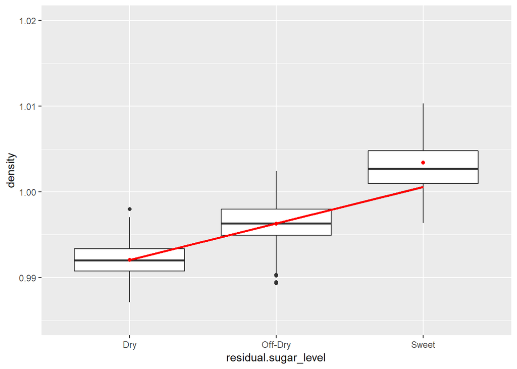

不同含糖量等级，随着含糖量的均值的增加，密度呈现增加的趋势。

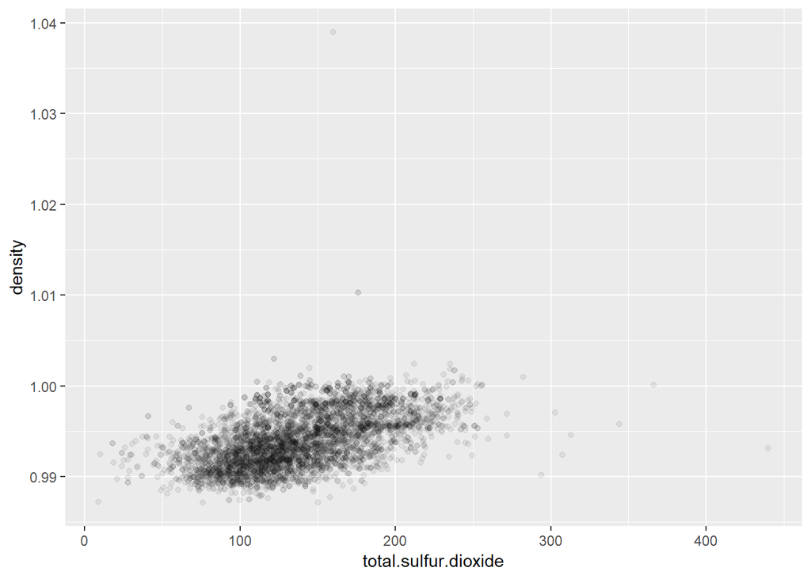

```
##
##  Pearson's product-moment correlation
##
## data:  wine_data$total.sulfur.dioxide and wine_data$density
## t = 43.719, df = 4896, p-value < 2.2e-16
## alternative hypothesis: true correlation is not equal to 0
## 95 percent confidence interval:
##  0.5094349 0.5497297
## sample estimates:
##       cor
## 0.5298813
```

对密度与二氧化硫含量之间的关系进行散点图探索分析，得出两者之间存在着相关性，相关系数为0.53，相关性中等。

3、下面分析酸度与PH值之间的关系。

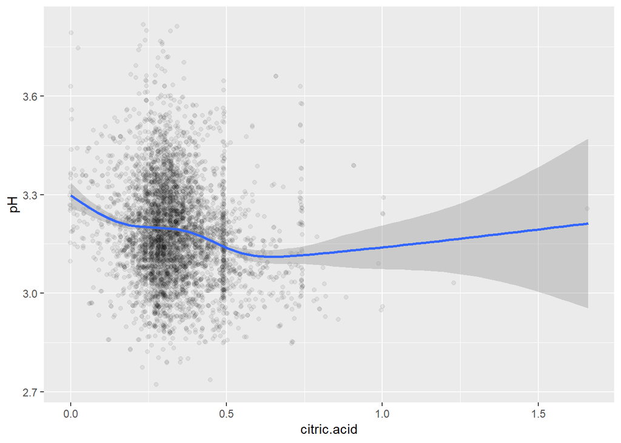

白葡萄酒随着柠檬酸的增加，PH逐渐降低。

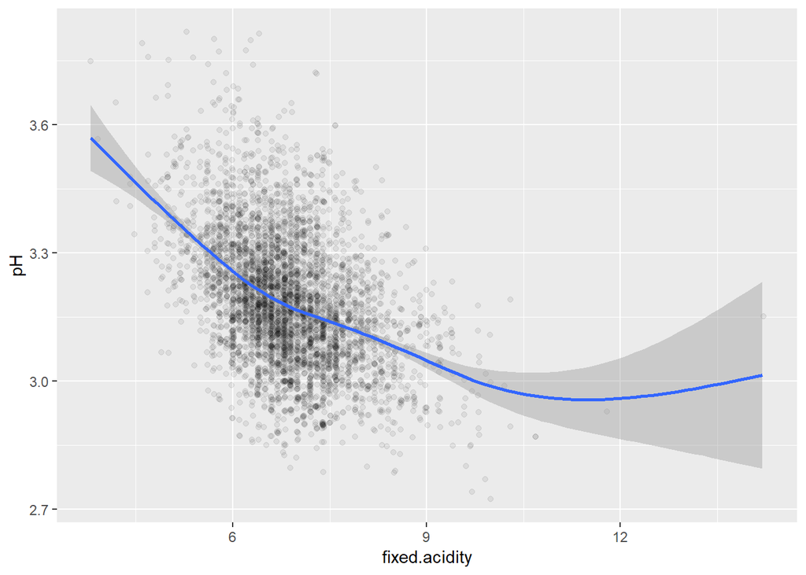

白葡萄酒随着固定酸的增加，PH逐渐降低。

4、下面对密度、PH值、酒精浓度与质量等级进行探索。

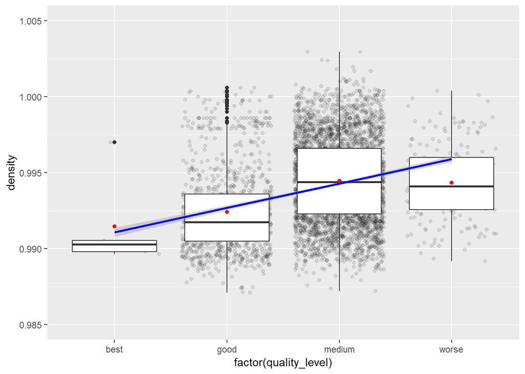

通过对白葡萄酒密度与质量等级进行绘图发现，随着质量等级的升高，密度的平均值是逐渐减少。

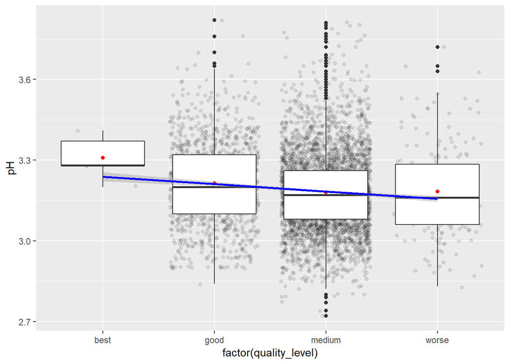

```
##
##  Pearson's product-moment correlation
##
## data:  wine_data$pH and wine_data$quality
## t = 6.9917, df = 4896, p-value = 3.081e-12
## alternative hypothesis: true correlation is not equal to 0
## 95 percent confidence interval:
##  0.07162022 0.12707983
## sample estimates:
##        cor
## 0.09942725
```

白葡萄酒的PH值与质量之间的相关性很小，相关系数0.099。从绘制的箱线图发现，随着白葡萄酒质量等级的增加，ph值逐渐升高。可见，白葡酒的质量越好，pH值越高。

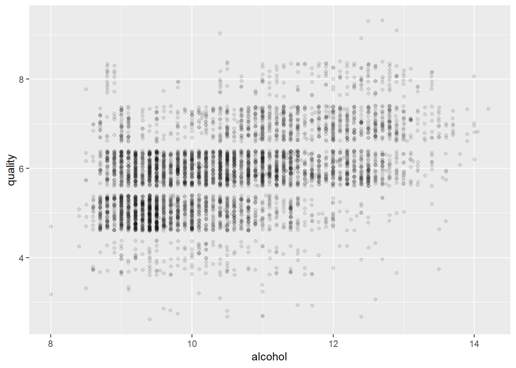

```
##
##  Pearson's product-moment correlation
##
## data:  wine_data$alcohol and wine_data$quality
## t = 33.858, df = 4896, p-value < 2.2e-16
## alternative hypothesis: true correlation is not equal to 0
## 95 percent confidence interval:
##  0.4126015 0.4579941
## sample estimates:
##       cor
## 0.4355747
```

通过对白葡萄酒酒精浓度与质量进行绘图与相关系数计算，得出相关系数是 0.44，相关性中等，说明酒精浓度一定程度会影响白葡萄酒的质量。

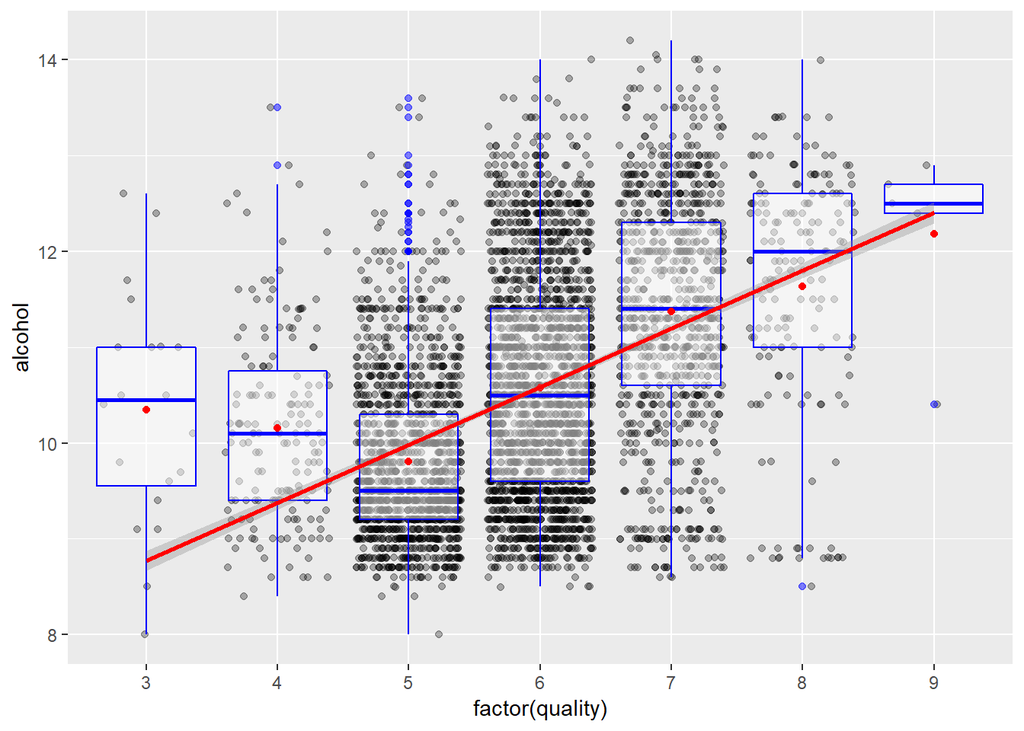

# 双变量分析

### 探讨你在这部分探究中观察到的一些关系。这些感兴趣的特性与数据集内其他特性有什么区别？

在此部分中探索了影响密度的几个特征，发现含糖量与密度的相关性最强，含糖量等级越高，密度越高。其次是与二氧化硫含量相关性中等。 探索了影响PH值的几个酸度特征， 发现pH值随着柠檬酸和固定酸的增加而降低。  
对质量的分析发现，质量与密度均值呈现负相关，质量等级越高，密度越小；质量与PH值之间呈现正相关，质量越高，pH值越高；最后是酒精浓度与质量的关系，酒精浓度越高，质量越高。

### 你是否观察到主要特性与其他特性之间的有趣关系？

在分析中发现白葡萄酒的含含糖量量越高，对应的密度会越高，但是密度与白葡萄酒之间的相关性又不是那么强。猜想含糖量与密度会不会对白葡萄酒的质量有影响呢。

### 你发现最强的关系是什么？

通过对目前的可视化分析得出的最强的关系是，含糖量与密度之间具有很强的正相关性。

# 多变量绘图选择

本次探索主要研究的是哪些特征会影响白葡萄酒的质量，但是通过单变量与双变量的探索分析，仍然没有发现相关性极强的特征，接下来我们将继续进行多变量探索。

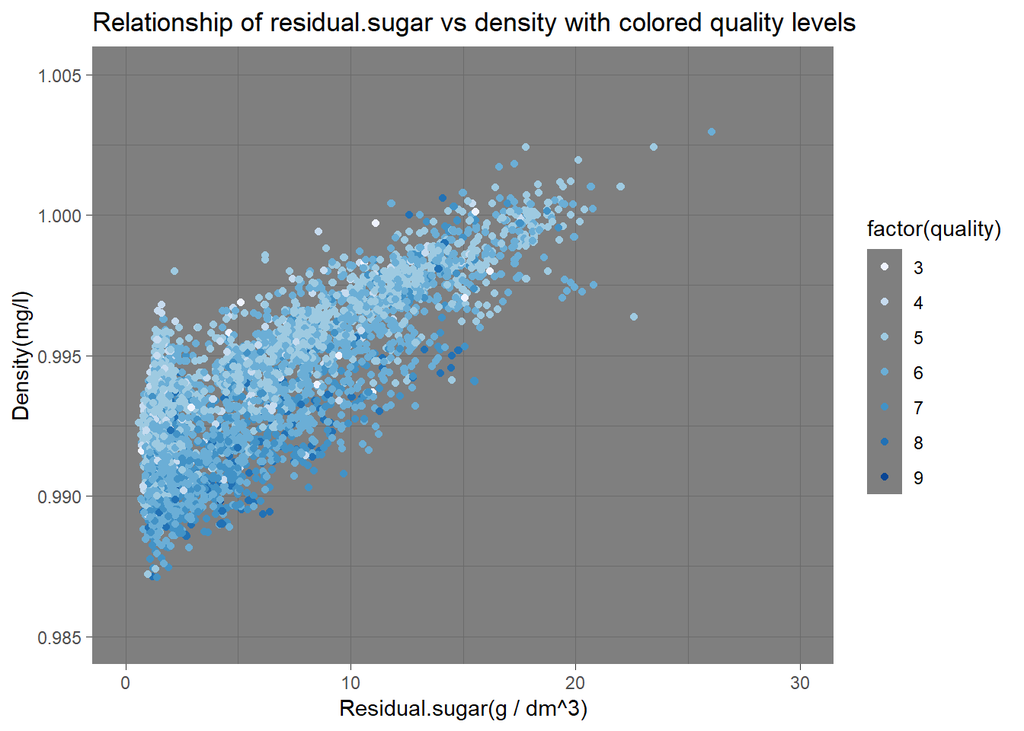

质量较高的白葡萄酒的密度处于较低的水平，随着含糖量含量的增加，密度逐渐增加。下面探索酒精浓度、密度与质量之间的关系。  
下面对不同等级质量的酒精浓度与密度之间进行探索。

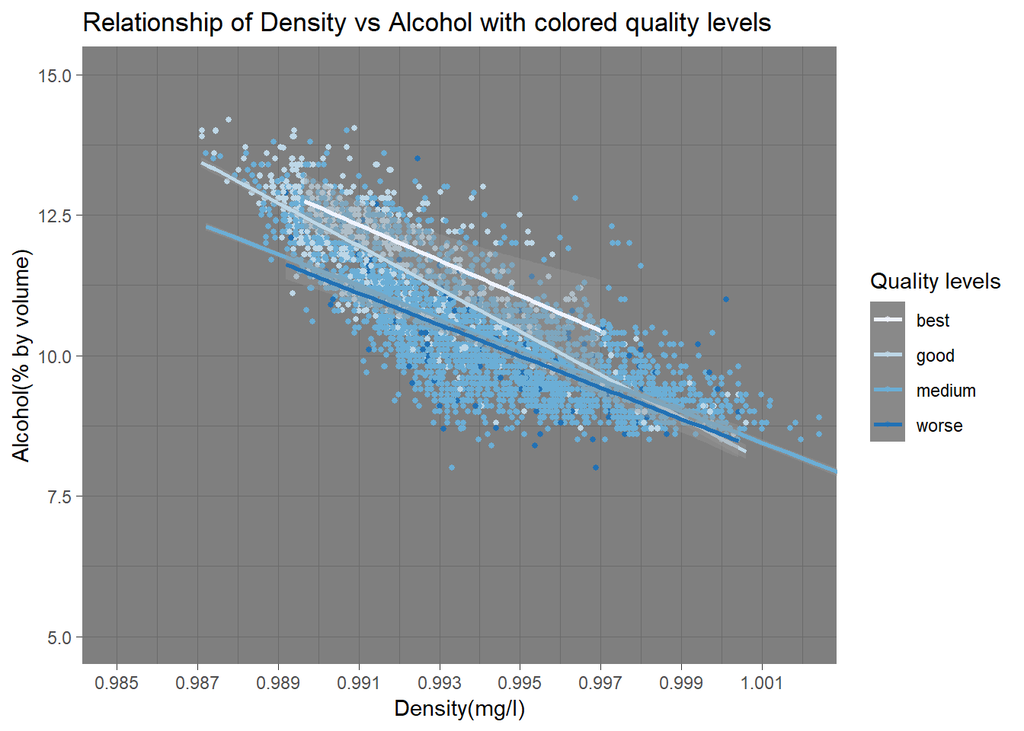

由以上分析发现酒精浓度与密度之间存在着很强的相关性，随着酒精浓度的升高，密度逐渐降低，不同质量的白葡萄酒也是此趋势。

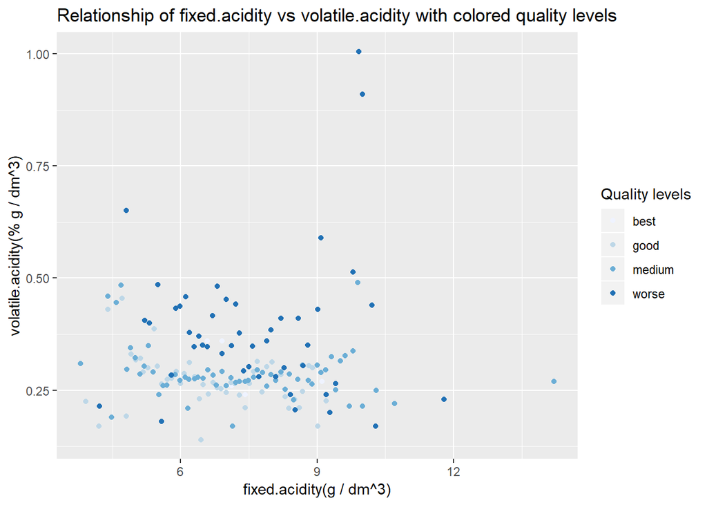

```
##
## Calls:
## m1: lm(formula = I(log(quality)) ~ I(alcohol), data = wine_data)
## m2: lm(formula = I(log(quality)) ~ I(alcohol) + density, data = wine_data)
## m3: lm(formula = I(log(quality)) ~ I(alcohol) + density + residual.sugar,
##     data = wine_data)
## m4: lm(formula = I(log(quality)) ~ I(alcohol) + density + residual.sugar +
##     total.sulfur.dioxide, data = wine_data)
## m5: lm(formula = I(log(quality)) ~ I(alcohol) + density + residual.sugar +
##     total.sulfur.dioxide + sulphates, data = wine_data)
##
## ==============================================================================================
##                              m1            m2            m3            m4            m5
## ----------------------------------------------------------------------------------------------
##   (Intercept)               1.208***     -3.087**      17.357***     17.961***     22.021***
##                            (0.017)       (1.080)       (2.167)       (2.217)       (2.272)
##   I(alcohol)                0.052***      0.061***      0.040***      0.040***      0.035***
##                            (0.002)       (0.003)       (0.003)       (0.003)       (0.003)
##   density                                 4.236***    -16.174***    -16.792***    -20.895***
##                                          (1.065)       (2.157)       (2.210)       (2.266)
##   residual.sugar                                        0.010***      0.010***      0.011***
##                                                        (0.001)       (0.001)       (0.001)
##   total.sulfur.dioxide                                                0.000         0.000
##                                                                      (0.000)       (0.000)
##   sulphates                                                                         0.133***
##                                                                                    (0.018)
## ----------------------------------------------------------------------------------------------
##   R-squared                 0.176         0.179         0.198         0.198         0.207
##   adj. R-squared            0.176         0.179         0.198         0.198         0.207
##   sigma                     0.140         0.139         0.138         0.138         0.137
##   F                      1047.148       533.062       403.038       302.724       255.946
##   p                         0.000         0.000         0.000         0.000         0.000
##   Log-likelihood         2691.591      2699.488      2757.638      2758.452      2786.019
##   Deviance                 95.550        95.242        93.007        92.976        91.936
##   AIC                   -5377.182     -5390.976     -5505.275     -5504.905     -5558.037
##   BIC                   -5357.693     -5364.990     -5472.792     -5465.925     -5512.561
##   N                      4898          4898          4898          4898          4898
## ==============================================================================================
```

该线性模型中的变量占白葡萄酒质量的20%，可见这些变量对白葡萄酒质量的影响一般。

# 多变量分析

### 选项：你是否创建过数据集的任何模型？讨论你模型的优缺点。

最后对quality、alcohol、density、residual.sugar、total.sulfur.dioxide、sulphates这几个特征构建的线性模型，得出这些特征在白葡萄酒质量的20%。

# 定稿图与总结

### 绘图一

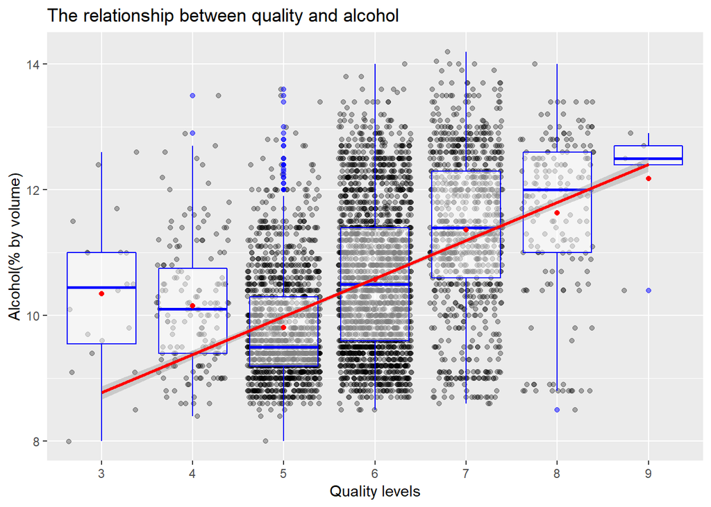

### 绘图二

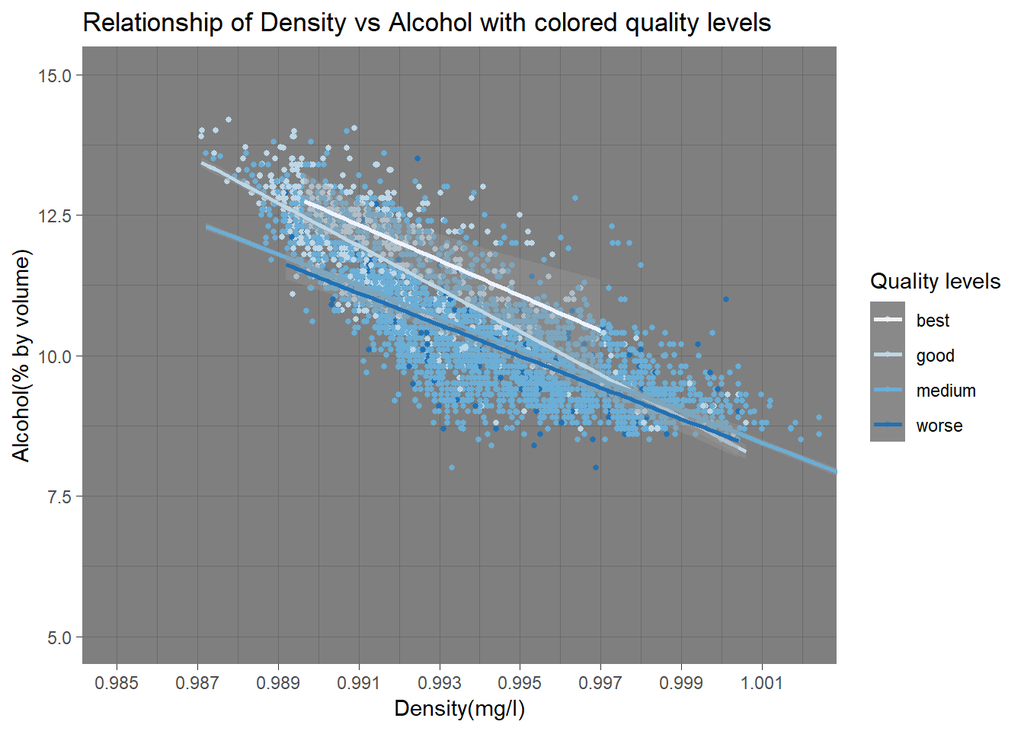

### 描述二

不同质量的葡萄酒，随着酒精浓度的减少，密度逐渐增加。白葡萄酒的质量等级越高，相应的酒精含量越高，质量等级越差，酒精浓度分布在较低区域。

### 绘图三

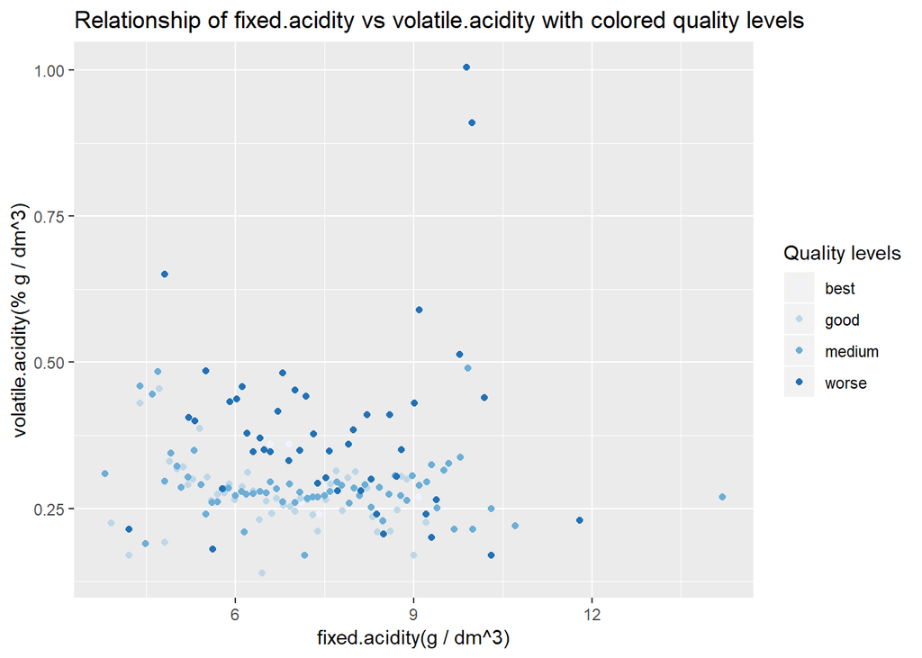

### 描述三

# 反思

在对该数据集探索分析时，首先对数据集中特征进行单变量探索，探索他们在市场分布的状况。同时还增加了白葡萄质量等级、含糖量等级的变量，并对其进行了相关探索。其次对数据集中的相关性进行研究，在双变量分析时探索了几个相关性强的变量，以及与质量相关性强的变量。多变量分析中，增加变量对几个特征进行探索。

在探索过程，刚开始对其进行探索并没有发现与质量很强关系的特征。但是随着探索的逐步深入以及变量的增加，还是有一点发现，比如发现了酒精浓度与白葡萄酒质量之间存在着的的相关性；含糖量与密度之间的存在的极强相关性。后面根据这些相关性进行了密度与酒精浓度对质量影响的探索，同时发现了不同质量等级的白葡萄酒之间酒精浓度与密度的关系。

对该数据集的探索，我应该还有很多方面可以继续探索，比如pH值与酸对不同质量的白葡萄酒是否有影响，或是不同添加剂会不会对白葡萄酒产生影响。或者采取更加合理的线性模型对其进行分析等等。